# 14 Limits

## 14.5 Limits from the definition

The formal definition of a limit involves clarifying what it means for $f(x)$ to be “close to $L$” when $x$ is “close to $c$”. These are quantified by the inequalities $0 < \lvert x-c\rvert < \delta$ and the $\lvert f(x) - L\rvert < \epsilon$. The second does not have the restriction that it is greater than $0$, as indeed $f(x)$ can equal $L$. The order is important: it says for any idea of close for $f(x)$ to $L$, an idea of close must be found for $x$ to $c$.

The key is identifying a value for $\delta$ for a given value of $\epsilon$.

A simple case is the linear case. Consider the function $f(x) = 3x + 2$. Verify that the limit at $c=1$ is $5$.

We show “numerically” that $\delta = \epsilon/3$.

```r
f(x) = 3x + 2
c, L = 1, 5
epsilon = rand()                 # some number in (0,1)
delta = epsilon / 3
xs = c + delta * rand(100)       # 100 numbers, c < x < c + delta
as = [abs(f(x) - L) < epsilon for x in xs]
all(as)                          # are all the as true?
```

```r
## true
```

These lines produce a random $\epsilon$, the resulting $\delta$, and then verify for 100 numbers within $(c, c+\delta)$ that the inequality $\lvert f(x) - L \rvert < \epsilon$ holds for each. Running them again and again should always produce `true` if $L$ is the limit and $\delta$ is chosen properly.

(Of course, we should also verify values to the left of $c$.)

If there is worry about the possibility that `epsilon == 0`, we could replace its definition with `epsilon = max(eps(), rand())`.

In this case, $\delta$ is easy to guess, as the function is linear and has slope $3$. This basically says the $y$ scale is 3 times the $x$ scale. For non-linear functions, finding $\delta$ for a given $\epsilon$ can be a challenge. For the function $f(x) = x^3$, illustrated below, a value of $\delta=\epsilon^{1/3}$ is used for $c=0$:

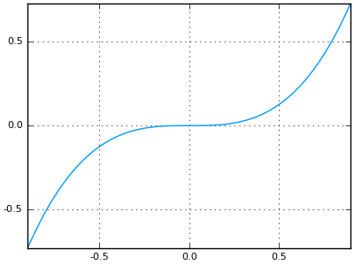

## 14.6 Questions

###### 14.6.0.0.0.3 Question

Graphically investigate the limit
$$~
L = \lim_{x \rightarrow 0} \frac{e^x - 1}{x}.
~$$

What is the value of $L$?

###### 14.6.0.0.0.4 Question

Graphically investigate the limit
$$~
\lim_{x \rightarrow 0} \frac{\cos(x) - 1}{x}.
~$$

The limit exists, what is the value?

###### 14.6.0.0.0.5 Question

The following limit is commonly used:
$$~
\lim_{h \rightarrow 0} \frac{e^{x + h} - e^x}{h} = L.
~$$

Factoring out $e^x$ from the top and using rules of limits this becomes,
$$~
L = e^x \lim_{h \rightarrow 0} \frac{e^h - 1}{h}.
~$$

What is $L$?

$e^x$

$0$

$1$

###### 14.6.0.0.0.6 Question

The following limit is commonly used:
$$~
\lim_{h \rightarrow 0} \frac{\sin(x + h) - \sin(x)}{h} = L.
~$$

The answer should depend on $x$, though it is possible it is a constant. Using a double angle formula and the rules of limits, this can be written as:
$$~
L = \cos(x) \lim_{h \rightarrow 0}\frac{\sin(h)}{h} + \sin(x) \lim_{h \rightarrow 0}\frac{\cos(h)-1}{h}.
~$$

Using the last result, what is the value of $L$?

$\cos(x)$

$\sin(x)$

$\sin(h)/h$

0

1

###### 14.6.0.0.0.7 Question Squeeze theorem

Let’s look at the function $f(x) = x \sin(1/x)$. A graph around $0$ can be made with:

```r
f(x) = x == 0 ? NaN : x * sin(1/x)
c, delta = 0, 1/4
plot([f, abs, x -> -abs(x)], c - delta, c + delta)
```

[output not shown]

This graph clearly oscillates near $0$. To the graph of $f$, we added graphs of both $g(x) = \lvert x\rvert$ and $h(x) = - \lvert x\rvert$. From this graph it is easy to see by the “squeeze theorem” that the limit at $x=0$ is $0$. Why?

The functions g and h squeeze each other as g(x) > h(x)

The function f has no limit – it oscillates too much near 0

The functions g and h both have a limit of 0 at x=0 and the function f is in between both g and h, so must to have a limit of 0.

###### 14.6.0.0.0.8 Question

Find the limit as $x$ goes to $2$ of
$$~
f(x) = \frac{3x^2 - x -10}{x^2 - 4}
~$$

###### 14.6.0.0.0.9 Question

Find the limit as $x$ goes to $-2$ of
$$~
f(x) = \frac{\frac{1}{x} + \frac{1}{2}}{x^3 + 8}
~$$

###### 14.6.0.0.0.10 Question

Find the limit as $x$ goes to $27$ of
$$~
f(x) = \frac{x - 27}{x^{1/3} - 3}
~$$

###### 14.6.0.0.0.11 Question

Find the limit
$$~
L = \lim_{x \rightarrow \pi/2} \frac{\tan (2x)}{x - \pi/2}
~$$

###### 14.6.0.0.0.12 Question

The limit of $\sin(x)/x$ at $0$ has a numeric value. This depends upon the fact that $x$ is measured in radians. Try to find this limit: `limit(sind(x)/x, x, 0)`. What is the value?

`1`

`pi/180`

`180/pi`

`0`

What is the limit `limit(sinpi(x)/x, x, 0)`?

`1`

`0`

`1/pi`

`pi`

###### 14.6.0.0.0.13 Question limit properties

There are several properties of limits that allow one to break down more complicated problems into smaller subproblems. For example,
$$~
\lim (f(x) + g(x)) = \lim f(x) + \lim g(x)
~$$

is notation to indicate that one can take a limit of the sum of two function or take the limit of each first, then add and the answer will be unchanged, provided all the limits in question exist.

Use one or the either to find the limit of $f(x) = \sin(x) + \tan(x) + \cos(x)$ as $x$ goes to $0$.

###### 14.6.0.0.0.14 Question

Does this function have a limit as $h$ goes to $0$ from the right (that is, assume $h>0$)?
$$~
\frac{h^h - 1}{h}
~$$

Yes, the value is `-11.5123`

No, the value heads to negative infinity

Yes, the value is `-9.2061`

###### 14.6.0.0.0.15 Question

Compute the limit
$$~
\lim_{x \rightarrow 1} \frac{x}{x-1} - \frac{1}{\log(x)}.
~$$

###### 14.6.0.0.0.16 Question

Compute the limit
$$~
\lim_{x \rightarrow 1/2} \frac{1}{\pi} \frac{\cos(\pi x)}{1 - (2x)^2}.
~$$